# Regression

2021-01-04

**Kernfragen dieser Lehreinheit**

- Wie kann ein Modell für den Zusammenhang von zwei Variablen erstellt werden?
- Wie können Streudiagramme in R erstellt werden? Wie kann die Regressionsgerade in den Plot eingefügt werden?
- Wie können standardisierte Regressionsgewichte geschätzt werden? Was ist der Unterschied zu nicht-standardisierten?
- Wie wird der Determinationskoeffizient $R^2$ berechnet und was sagt er aus?
- Wie werden der Korrelationskoeffizient *r* als auch das Regressionsparameter *b* inferenzstatistisch überprüft?

## Datensatz laden

Zu Beginn laden wir wie gewohnt den Datensatz (Sie können den Datensatz hier herunterladen) und erstellen, falls nötig, Labels und Skalenwerte.

[output not shown]

```r
setwd(...) #auf Pfad mit Datensatz
```

```r
load("fb20.rda")

#Labels
fb20$fach <- factor(fb20$fach, levels = 1:5, labels = c ('Allgemeine', 'Biologische', 'Entwicklung', 'Klinische', 'Diag./Meth.'))
fb20$ziel <- factor(fb20$ziel, levels = 1:4, labels = c ('Wirtschaft', 'Therapie', 'Forschung', 'Andere'))

#Rekodierung
fb20$mdbf4_r <- -1 * (fb20$mdbf4 - 6)
fb20$mdbf11_r <- -1 * (fb20$mdbf11 - 6)
fb20$mdbf5_r <- -1 * (fb20$mdbf5 - 6)
fb20$mdbf7_r <- -1 * (fb20$mdbf7 - 6)
fb20$mdbf3_r <- -1 * (fb20$mdbf3 - 6)
fb20$mdbf9_r <- -1 * (fb20$mdbf5 - 9)

#Skalenwerte
gut <- fb20[,c('mdbf1','mdbf4_r','mdbf8','mdbf11_r')]
fb20$gs <- rowMeans(gut)
wach <- fb20[,c('mdbf2','mdbf5_r','mdbf7_r','mdbf10')]
fb20$wm <- rowMeans(wach)
ruhig <- fb20[,c('mdbf3_r','mdbf6','mdbf9_r','mdbf12')]
fb20$ru <- rowMeans(ruhig)
```

## Lineare Regression

Nachdem wir mit der Korrelation mit der gemeinsamen Betrachtung von zwei Variablen begonnen haben, werden wir jetzt lineare Modelle erstellen, Plots inklusive Regressionsgerade für Zusammenhänge anzeigen lassen und Determinationskoeffizienten berechnen. Hierzu betrachten wir folgende Fragestellung:

- Hat die Extraversion (*extra*) einen Einfluss auf die Lebenszufriedenheit (*lz*)?

### Voraussetzungen:

1. Linearität: Zusammenhang muss linear sein $\rightarrow$ Grafische Überprüfung (Scatterplot)
2. Varianzhomogenität (Homoskedastizität) der Fehler: der Fehler jedes Wertes der UV hat annährend die gleiche Varianz
3. Normalverteilung der Fehlervariablen
4. Unabhängigkeit der Fehler

Die Voraussetzungen 2-4 können erst geprüft werden, nachdem das Modell schon gerechnet wurde, weil sie sich auf die Fehler (Residuen: Differenz aus beobachtetem und vorhergesagtem Wert für y) beziehen!

**zu 1. Linearität: Zusammenhang muss linear sein $\rightarrow$ Grafische Überprüfung (Scatterplot)**

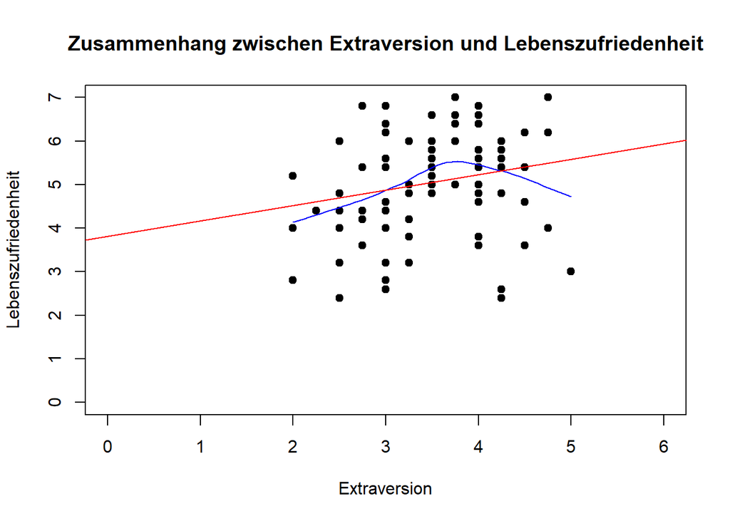

```r
plot(fb20$extra, fb20$lz, xlab = "Extraversion", ylab = "Lebenszufriedenheit",
     main = "Zusammenhang zwischen Extraversion und Lebenszufriedenheit", xlim = c(0, 6), ylim = c(0, 7), pch = 19)
lines(loess.smooth(fb20$extra, fb20$lz), col = 'blue')    #beobachteter, lokaler Zusammenhang
fm <- lm(lz ~ extra, fb20)                              #Modell erstellen und ablegen
abline(fm, col = "red")                                  #Modellierter linearer Zusammenhang in zuvor erstellten Plot einzeichnen
```

- `pch` verändert die Darstellung der Datenpunkte
- `xlim` und `ylim` veränderen die X- bzw. Y-Achse
- mit `cex` könnte man noch die Größe der Datenpunkte anpassen

**zu Voraussetzungen 2-4:**

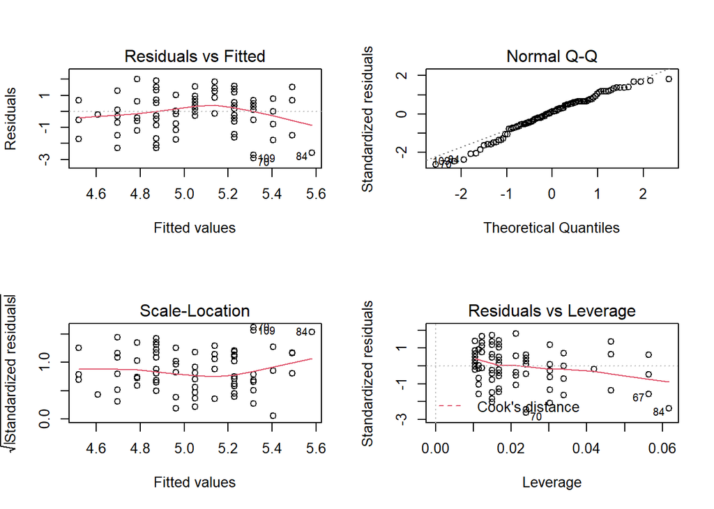

```r
par(mfrow = c(2, 2)) #Vier Abbildungen gleichzeitig
plot(fm)
```

```r
par(mfrow = c(1, 1)) #wieder auf eine Abbildung zurücksetzen
```

*Interpretation der Abbildungen:*

- Residuals vs. Fitted: geeignet um Abweichungen von der Linearität und Verletzungen der Homoskedastizität aufzudecken $\rightarrow$ soll möglichst unsystematisch aussehen, rote Anpassungslinie (y-MW bedingt auf X) verläuft parallel zur x-Achse
- Normal Q-Q: Zeigt Annäherung der Normalverteilung durch Residuen $\rightarrow$ Punkte sollen auf die Diagonalen liegen
- Scale-Location: Prüfung der Homoskedastizität, zeigt Zusammenhang zwischen Streuung der Residuen und vorhergesagten Werten $\rightarrow$ rote Anpassungslinie (y-MW bedingt auf X) verläuft parallel zur x-Achse
- Residuals vs. Leverage: zur Identifikation einflussreicher Datenpunkte $\rightarrow$ es sollen keine Fälle außerhalb der Intervalle liegen, rote Anpassungslinie (y-MW bedingt auf X) verläuft parallel zur x-Achse

In diesem Fall ist alles weitestgehend erfüllt.

Beispiel für schlechte Ergebnisse: https://data.library.virginia.edu/diagnostic-plots/

**Alternativer Weg zur Prüfung der Normalverteilung der Residuen**

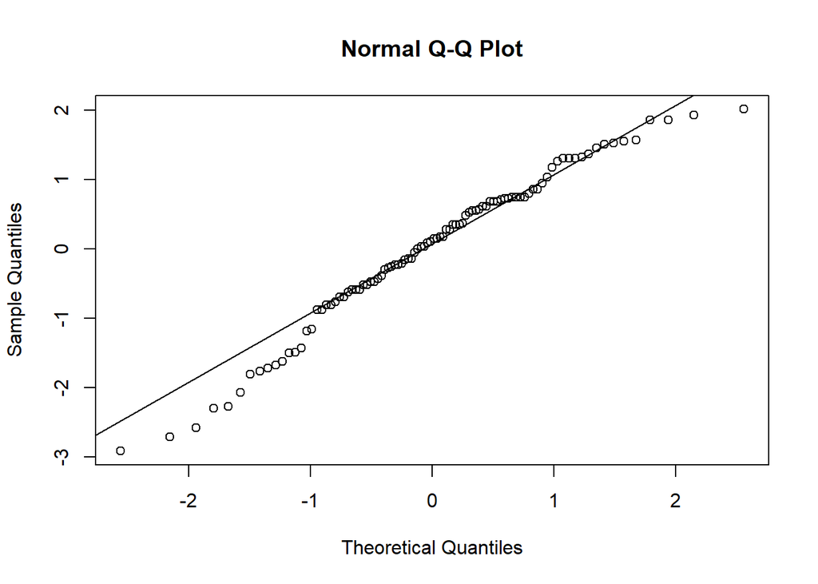

```r
res1 <- residuals(lm(lz ~ extra, fb20))   #Residuen speichern

#QQ
qqnorm(res1)
qqline(res1)
```

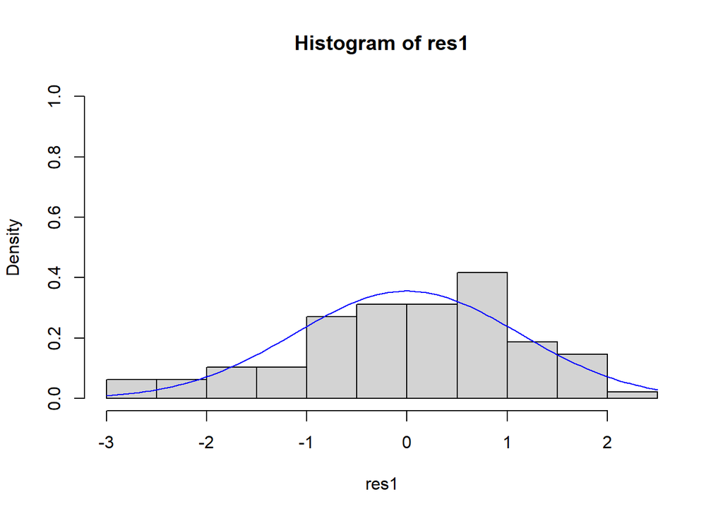

```r
#Histogramm
hist(res1, prob = T,ylim = c(0,1))    #prob: TRUE, da wir uns auf die Dichte beziehen
curve(dnorm(x,
            mean = mean(res1, na.rm = T),
            sd = sd(res1, na.rm = T)),
      main = "Histogram of residuals", ylab = "Residuals",
      col = "blue", add = T)   #add: soll Kurve in Grafik hinzugefügt werden?
```

```r
#Shapiro
shapiro.test(res1)
```

```
##
##  Shapiro-Wilk normality test
##
## data:  res1
## W = 0.97154, p-value = 0.03473
```

### Modellschätzung

Die Modellgleichung für die lineare Regression, wie sie in der Vorlesung besprochen wurde, lautet: $y_i = b_0 + b_1 x_i + e_i$

In R gibt es eine interne Schreibweise, die sehr eng an diese Form der Notation angelehnt ist. Mit `?formula` können Sie sich detailliert ansehen, welche Modelle in welcher Weise mit dieser Notation dargestellt werden können. R verwendet diese Notation für (beinahe) alle Modelle, sodass es sich lohnt, sich mit dieser Schreibweise vertraut zu machen. Die Kernelemente sind im Fall der linearen Regression

```r
y ~ 1 + x
```

Diese Notation enthält fünf Elemente:

- `y`: die abhängige Variable
- `~`: die Notation für “regressiert auf” oder “vorhergesagt durch”
- `1`: die Konstante 1
- `+`: eine additive Verknüpfung der Elemente auf der rechten Seite der Gleichung
- `x`: eine unabhängige Variable

Die Notation beschreibt also die Aussage “$y$ wird regressiert auf die Konstante $1$ und die Variable $x$”. Die zu schätzenden Parameter $b_0$ und $b_1$ werden in dieser Notation nicht erwähnt, weil sie uns unbekannt sind.

R geht generell davon aus, dass immer auch der Achsenabschnitt $b_0$ geschätzt werden soll, sodass `y ~ x` ausreichend ist, um eine Regression zu beschreiben. Wenn das Intercept unterdrückt werden soll, muss das mit `y ~ 0 + x` explizit gemacht werden.

In unserem Beispiel ist $x$ die Extraversion (`extra`) und $y$ die Lebenszufriedenheit (`lz`). Um das Modell zu schätzen wird dann der `lm` (für “linear model”) Befehl genutzt:

```r
lm(formula = lz ~ 1 + extra, data = fb20)
```

```
##
## Call:
## lm(formula = lz ~ 1 + extra, data = fb20)
##
## Coefficients:
## (Intercept)        extra
##      3.8119       0.3538
```

So werden die Koeffizienten direkt ausgegeben. Wir haben das Modell bereits abgespeichern, da wir es für die Überprüfung der Voraussetzungen benötigt haben. Hierzu muss das Modell einem Objekt zugewiesen werden. Hier in verkürzter Schreibweise:

```r
fm <- lm(lz ~ extra, fb20)
```

Aus diesem Objekt können mit `coef` die geschätzten Koeffizienten extrahiert werden:

```r
coef(fm)
```

```
## (Intercept)       extra
##    3.811938    0.353777
```

Falls man sich unsicher ist, wie dieses Modell zustande gekommen ist, kann man dies ausdrücklich erfragen:

```r
formula(fm)
```

```
## lz ~ extra
```

```r
residuals(fm)
```

```
##           23           27           29           39           40           42
##  0.349842626  1.572954137 -0.050157374 -1.184824640  0.284509892  0.526731115
##           43           47           48           49           51           54
## -0.250157374 -1.627045863  0.038286871  0.349842626  1.507621403  0.038286871
##           64           65           66           67           68           70
## -0.227045863 -0.161713129  0.726731115 -1.719491906 -0.696380396 -2.915490108
##           71           72           73           78           79           81
##  1.372954137  0.861398381  1.261398381  0.707621403  0.749842626  0.796065647
##           84           85           86           89           90           93
## -2.580822842  0.149842626 -1.492378597 -0.627045863  1.303619604  1.549842626
##           94           95           97           98          103          105
##  0.861398381  0.172954137 -0.873268885  1.861398381 -1.673268885 -0.296380396
##          108          109          110          114          115          116
## -0.427045863 -2.715490108 -0.384824640  0.680508094  0.549842626 -0.273268885
##          117          118          119          120          121          122
##  1.303619604  0.684509892 -0.696380396  1.303619604  0.726731115 -0.473268885
##          124          125          128          131          132          133
##  0.349842626 -0.138601619 -0.584824640  0.284509892  1.526731115 -2.296380396
##          136          137          138          139          141          142
##  0.084509892  0.615175360  0.549842626 -0.227045863 -0.803934353 -2.273268885
##          143          145          146          147          148          149
## -1.803934353  1.926731115 -1.161713129 -0.803934353 -0.584824640 -1.496380396
##          151          152          155          156          157          159
##  0.684509892  1.172954137 -0.138601619  1.861398381 -2.073268885  0.749842626
##          162          163          164          166          170          173
## -0.873268885  2.015175360  0.949842626  0.103619604  0.749842626  0.572954137
##          174          176          178          181          183          184
##  1.038286871  0.749842626 -1.761713129 -0.761713129  0.484509892 -0.207936151
##          186          188          189          190          191          192
## -0.515490108 -0.519491906 -1.427045863 -0.473268885  1.461398381  0.372954137
##          193          198          200          201          203          208
## -0.584824640  0.172954137  0.149842626  0.615175360  1.326731115 -0.003934353
```

Die folgenden Ergebnisse aus `fm` werden wir verwenden. In `coef(fm)` stehen die Regressionskoeffizienten $b_0$ unter `(Intercept)` zur Konstanten gehörend und $b_1$ unter dem Namen der Variable, die wir als Prädiktor nutzen. In diesem Fall also `extra`. Die Regressionsgleichung hat daher die folgende Gestalt: $y_i = 3.81 + 0.35 \cdot x + e_i$.

Regressionsgleichung (unstandardisiert):

$$\hat{y} = b_0 + b_1*x_i$$
$$\hat{y} = 3.81 + 0.35*x_i$$

### Vorhergesagte Werte

Die vorhergesagten Werten $\hat{y}$ können mit `predict` ermittelt werden:

```r
predict(fm)
```

```
##       23       27       29       39       40       42       43       47
## 5.050157 5.227046 5.050157 4.784825 5.315490 4.873269 5.050157 5.227046
##       48       49       51       54       64       65       66       67
## 4.961713 5.050157 5.492379 4.961713 5.227046 4.961713 4.873269 4.519492
##       68       70       71       72       73       78       79       81
## 4.696380 5.315490 5.227046 5.138602 5.138602 5.492379 5.050157 5.403934
##       84       85       86       89       90       93       94       95
## 5.580823 5.050157 5.492379 5.227046 4.696380 5.050157 5.138602 5.227046
##       97       98      103      105      108      109      110      114
## 4.873269 5.138602 4.873269 4.696380 5.227046 5.315490 4.784825 4.519492
##      115      116      117      118      119      120      121      122
## 5.050157 4.873269 4.696380 5.315490 4.696380 4.696380 4.873269 4.873269
##      124      125      128      131      132      133      136      137
## 5.050157 5.138602 4.784825 5.315490 4.873269 4.696380 5.315490 4.784825
##      138      139      141      142      143      145      146      147
## 5.050157 5.227046 5.403934 4.873269 5.403934 4.873269 4.961713 5.403934
##      148      149      151      152      155      156      157      159
## 4.784825 4.696380 5.315490 5.227046 5.138602 5.138602 4.873269 5.050157
##      162      163      164      166      170      173      174      176
## 4.873269 4.784825 5.050157 4.696380 5.050157 5.227046 4.961713 5.050157
##      178      181      183      184      186      188      189      190
## 4.961713 4.961713 5.315490 4.607936 5.315490 4.519492 5.227046 4.873269
##      191      192      193      198      200      201      203      208
## 5.138602 5.227046 4.784825 5.227046 5.050157 4.784825 4.873269 5.403934
```

Per Voreinstellung werden hier die vorhergesagten Werte aus unserem ursprünglichen Datensatz dargestellt. `predict` erlaubt uns aber auch Werte von “neuen” Beobachtungen vorherzusagen. Nehmen wir an, wir würden die Extraversion von 5 neuen Personen beobachten (sie haben - vollkommen zufällig - die Werte 1, 2, 3, 4 und 5) und diese Beobachtungen in einem neuem Datensatz `extra_neu` festhalten:

```r
extra_neu <- data.frame(extra = c(1, 2, 3, 4, 5))
```

Anhand unseres Modells können wir für diese Personen auch ihre Lebenszufriedenheit vorhersagen, obwohl wir diese nicht beobachtet haben:

```r
predict(fm, newdata = extra_neu)
```

```
##        1        2        3        4        5
## 4.165715 4.519492 4.873269 5.227046 5.580823
```

Damit diese Vorhersage funktioniert, muss im neuen Datensatz eine Variable mit dem Namen `extra` vorliegen.

Der Anteil der Variabilität, der durch das Modell nicht erklärt werden kann - die Residuen $e_m$ - können mit `resid` abgefragt werden:

```r
resid(fm)
```

```
##           23           27           29           39           40           42
##  0.349842626  1.572954137 -0.050157374 -1.184824640  0.284509892  0.526731115
##           43           47           48           49           51           54
## -0.250157374 -1.627045863  0.038286871  0.349842626  1.507621403  0.038286871
##           64           65           66           67           68           70
## -0.227045863 -0.161713129  0.726731115 -1.719491906 -0.696380396 -2.915490108
##           71           72           73           78           79           81
##  1.372954137  0.861398381  1.261398381  0.707621403  0.749842626  0.796065647
##           84           85           86           89           90           93
## -2.580822842  0.149842626 -1.492378597 -0.627045863  1.303619604  1.549842626
##           94           95           97           98          103          105
##  0.861398381  0.172954137 -0.873268885  1.861398381 -1.673268885 -0.296380396
##          108          109          110          114          115          116
## -0.427045863 -2.715490108 -0.384824640  0.680508094  0.549842626 -0.273268885
##          117          118          119          120          121          122
##  1.303619604  0.684509892 -0.696380396  1.303619604  0.726731115 -0.473268885
##          124          125          128          131          132          133
##  0.349842626 -0.138601619 -0.584824640  0.284509892  1.526731115 -2.296380396
##          136          137          138          139          141          142
##  0.084509892  0.615175360  0.549842626 -0.227045863 -0.803934353 -2.273268885
##          143          145          146          147          148          149
## -1.803934353  1.926731115 -1.161713129 -0.803934353 -0.584824640 -1.496380396
##          151          152          155          156          157          159
##  0.684509892  1.172954137 -0.138601619  1.861398381 -2.073268885  0.749842626
##          162          163          164          166          170          173
## -0.873268885  2.015175360  0.949842626  0.103619604  0.749842626  0.572954137
##          174          176          178          181          183          184
##  1.038286871  0.749842626 -1.761713129 -0.761713129  0.484509892 -0.207936151
##          186          188          189          190          191          192
## -0.515490108 -0.519491906 -1.427045863 -0.473268885  1.461398381  0.372954137
##          193          198          200          201          203          208
## -0.584824640  0.172954137  0.149842626  0.615175360  1.326731115 -0.003934353
```

Diese können auch als neue Variable im Datensatz angelegt werden und hätten dort die Bedeutung des “Ausmaßes an Lebenszufriedenheit, das nicht durch Extraversion vorhergesagt werden kann” - also die Differenz aus vorhergesagtem und tatsächlich beobachtetem Wert der y-Variable (Lebenszufriedenheit).

### Streu-Punktdiagramm mit Regressionsgerade

Das Streudiagramm haben wir zu Beginn schon abbilden lassen. Hier kann zusätzlich noch der geschätzte Zusammenhang zwischen den beiden Variablen als Regressiongerade eingefügt werden. Hierzu wird der Befehl `plot` durch `abline` ergänzt:

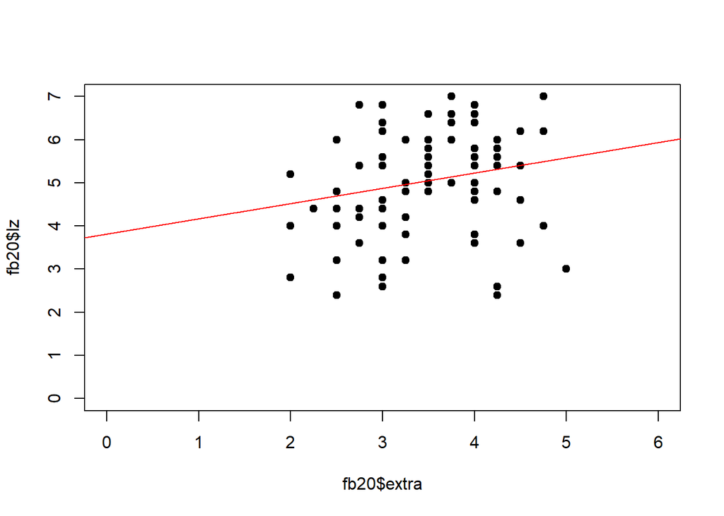

```r
# Scatterplot zuvor im Skript beschrieben
plot(fb20$extra, fb20$lz,
  xlim = c(0, 6), ylim = c(0, 7), pch = 19)

# Ergebnisse der Regression als Gerade aufnehmen
abline(fm, col = 'red')
```

### Standardisierte Regressionsgewichte

Bei einer Regression (besonders wenn mehr als ein Prädiktor in das Modell aufgenommen wird) kann es sinnvoll sein, die standardisierten Regressionskoeffizienten zu betrachten, um die Erklärungs- oder Prognosebeiträge der einzelnen unabhängigen Variablen (unabhängig von den bei der Messung der Variablen gewählten Einheiten) miteinander vergleichen zu können, z. B. um zu sehen, welche Variable den größten Beitrag zur Prognose der abhängigen Variable leistet. Außerdem ist es hierdurch möglich die Ergebnisse zwischen verschiedenen Studien zu vergleichen, die `lz` und `extra` gemessen haben, jedoch in unterschiedlichen Einheiten. Durch die Standardisierung werden die Regressionskoeffizienten vergleichbar. Die Variablen werden mit `scale` standardisiert (z-Transformation; Erwartungswert gleich Null und die Varianz gleich Eins gesetzt). Mit `lm` wird das Modell berechnet. Die Koeffizienten können über das Ausführen von `sfm` abgefragt werden:

```r
sfm <- lm(scale(lz) ~ scale(extra), fb20)
sfm
```

```
##
## Call:
## lm(formula = scale(lz) ~ scale(extra), data = fb20)
##
## Coefficients:
##  (Intercept)  scale(extra)
##     0.001836      0.213860
```

Das standardisierte Regressionsgewicht hat den gleichen *t*-Wert und *p*-Wert wie das unstandardisierte!

### Determinationskoeffizient $R^2$

Der Determinationskoeffizient $R^2$ ist eine Kennzahl zur Beurteilung der Anpassungsgüte einer Regression. Anhand dessen kann bewertet werden, wie gut Messwerte zu einem Modell passen. Das Bestimmtheitsmaß ist definiert als der Anteil, der durch die Regression erklärten Quadratsumme an der zu erklärenden totalen Quadratsumme, und gibt an, wie viel Streuung in den Daten durch das vorliegende lineare Regressionsmodell „erklärt“ werden kann. Bei einer einfachen Regression entspricht $R^2$ dem Quadrat des Korrelationskoeffizienten.

Um $R^2$ zu berechnen, gibt es verschiedene Möglichkeiten.

Für die Berechnung per Hand werden die einzelnen Varianzen benötigt:

$R^2 = \frac{s^2_{\hat{Y}}}{s^2_{Y}} = \frac{s^2_{\hat{Y}}}{s^2_{\hat{Y}} + s^2_{E}}$

```r
# Anhand der Varianz von lz
var(predict(fm)) / var(fb20$lz, use = "na.or.complete")
```

```
## [1] 0.04640696
```

```r
# Anhand der Summe der Varianzen
var(predict(fm)) / (var(predict(fm)) + var(resid(fm)))
```

```
## [1] 0.04640696
```

Jedoch kann dieser umständliche Weg umgangen werden. Mit der Funktion `summary` kann ein Überblick über verschiedene Variablen und auch Funktionen generiert werden. Für lineare Funktionen werden mit diesem Befehl unter anderem auch die Koeffizienten angezeigt. Anhand des p-Werts kann hier auch die Signifikanz des $R^2$ überprüft werden.

```r
#Detaillierte Modellergebnisse
summary(fm)
```

```
##
## Call:
## lm(formula = lz ~ extra, data = fb20)
##
## Residuals:
##     Min      1Q  Median      3Q     Max
## -2.9155 -0.5954  0.1267  0.7498  2.0152
##
## Coefficients:
##             Estimate Std. Error t value Pr(>|t|)
## (Intercept)   3.8119     0.5835   6.533 3.28e-09 ***
## extra         0.3538     0.1654   2.139    0.035 *
## ---
## Signif. codes:  0 '***' 0.001 '**' 0.01 '*' 0.05 '.' 0.1 ' ' 1
##
## Residual standard error: 1.126 on 94 degrees of freedom
##   (2 Beobachtungen als fehlend gelöscht)
## Multiple R-squared:  0.04641,    Adjusted R-squared:  0.03626
## F-statistic: 4.575 on 1 and 94 DF,  p-value: 0.03504
```

Determinationskoeffizient $R^2$ ist signifikant, da $p < \alpha$.

Der Determinationskoeffizient $R^2$ kann auch direkt über den Befehl `summary()$r.squared` ausgegeben werden:

```r
summary(fm)$r.squared
```

```
## [1] 0.04640696
```

4,6% der Varianz von `lz` können durch `extra` erklärt werden.Dieser Effekt ist nach Cohens (1988) Konvention als schwach zu bewerten.

**Exkurs: Cohens (1988) Konvention zur Interpretation von $R^2$:**

- ~ .01: schwacher Effekt
- ~ .09: mittlerer Effekt
- ~ .25: starker Effekt

## Inferenzstatistische Überprüfung des Regressionsparameter *b*

**Signifikanztestung der Regressionskoeffizienten:**

Zuerst kann die Betrachtung der Konfidenzintervalle helfen. Der Befehl `confint` berechnet die Konfidenzintervalle der Regressionsgewichte.

```r
#Konfidenzintervalle der Regressionskoeffizienten
confint(fm)
```

```
##                  2.5 %    97.5 %
## (Intercept) 2.65345912 4.9704168
## extra       0.02535619 0.6821978
```

Das Konfidenzintervall von 0.025 und 0.68 enthält mit einer 95%igen Wahrscheinlichkeit den wahren Wert für $b_1$. Damit ist die 0 nicht eingeschlossen und das Betagewicht ist von 0 verschieden.

- $b_1$
  - H0: $b_1 = 0$, das Regressionsgewicht ist nicht von Null verschieden.
  - H1: $b_1 \neq 0$, das Regressionsgewicht ist von Null verschieden.
- $b_0$ (häufig nicht von Interesse)
  - H0: $b_0 = 0$, der Achsenabschnitt ist nicht von Null verschieden.
  - H1: $b_0 \neq 0$, der Achsenabschnitt ist von Null verschieden.

```r
#Detaillierte Modellergebnisse
summary(fm)
```

```
##
## Call:
## lm(formula = lz ~ extra, data = fb20)
##
## Residuals:
##     Min      1Q  Median      3Q     Max
## -2.9155 -0.5954  0.1267  0.7498  2.0152
##
## Coefficients:
##             Estimate Std. Error t value Pr(>|t|)
## (Intercept)   3.8119     0.5835   6.533 3.28e-09 ***
## extra         0.3538     0.1654   2.139    0.035 *
## ---
## Signif. codes:  0 '***' 0.001 '**' 0.01 '*' 0.05 '.' 0.1 ' ' 1
##
## Residual standard error: 1.126 on 94 degrees of freedom
##   (2 Beobachtungen als fehlend gelöscht)
## Multiple R-squared:  0.04641,    Adjusted R-squared:  0.03626
## F-statistic: 4.575 on 1 and 94 DF,  p-value: 0.03504
```

Aus `summary()`: $p < \alpha$ $\rightarrow$ H1: Das Regressionsgewicht für den Prädiktor Extraversion ist signifikant von Null verschieden. Extraversion hat einen Einfluss auf die Lebenszufriedenheit.

Aus `summary()`: $p < \alpha$ $\rightarrow$ H1: der Achsenabschnitt ist signifikant von Null verschieden. Beträgt die Extraversion Null wird eine von 0 verschiedene Lebenszufriedenheit vorhergesagt.